# Chromosome compaction - simple three-state model

`r`r library(mylib) library(ChromCom) library(ggplot2) library(gridExtra) library(reshape2) library(parallel) library(latex2exp) binDir <- ../RData

This is a continuation of the previous notebook, mod3_notes_old, with a new model. In the old model, the start time $t_1$ was a fixed number, creating a cusp in the curve, while in the new model is a random variable with exponential distribution.

# 17/08/2017

`r`r pars <- c3pars( tau = 20, dt2 = 0, k1 = 0.04, k2 = 0.04 )

```
Error in c3pars(tau = 20, dt2 = 0, k1 = 0.04, k2 = 0.04) :
  argument 1 matches multiple formal arguments
```

## Experimental data

`r`r echr.scr <- experimentalData(dataFile$scramble) echr.d2 <- experimentalData(dataFile$NCAPD2) echr.d3 <- experimentalData(dataFile$NCAPD3) echr.smc <- experimentalData(dataFile$SMC2) echr.rad <- experimentalData(dataFile$RAD21) echr.mk <- experimentalData(dataFile$MK1775) #echr.mki <- experimentalData(dataFile$MK1775_ICRF193) plotTimelines(echr.scr, smooth=TRUE, k=15)

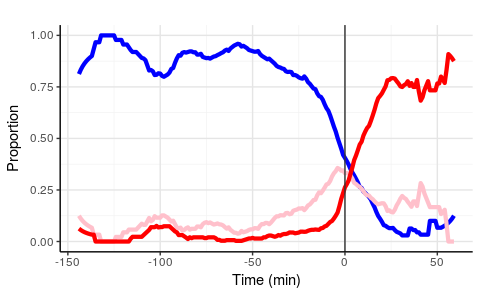

I start with fitting scramble

## Scramble

Fitting with $k_1$, $k_2$ and $tau$ free.

`r`r pars <- c3pars() free <- c(, 1, 2) #chr.scr <- cacheData(_scramble_n10000_tau_k1_k2, fitChr, echr.scr, pars, free, nsim=3000, ntry=32, ncores=6, binDir=binDir) #plotTimelines(chr.scr, expdata = echr.scr, withpars=TRUE)

`r`r pars <- c3pars() free <- c(, 1, 2, 2) chr.scr <- cacheData(_scramble_n10000_tau_k1_k2_dt2, fitChr, echr.scr, pars, free, nsim=10000, ntry=100, ncores=6, binDir=binDir) plotTimelines(chr.scr, expdata = echr.scr, withpars=TRUE)

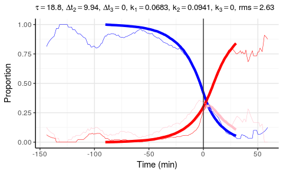

## NCAPD2

`r`r pars <- c3pars() free <- c(, 1, 2, 2) chr.d2 <- cacheData(_NCAPD2_n10000_tau_k1_k2_dt2, fitChr, echr.d2, pars, free, nsim=10000, ntry=100, ncores=6, binDir=binDir) plotTimelines(chr.d2, expdata = echr.d2, withpars=TRUE)

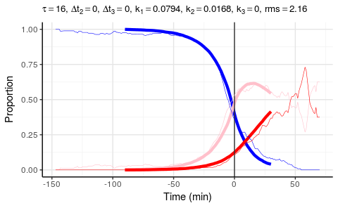

## NCAPD3

`r`r pars <- c3pars() free <- c(, 1, 2, 2) chr.d3 <- cacheData(_NCAPD3_n10000_tau_k1_k2_dt2, fitChr, echr.d3, pars, free, nsim=10000, ntry=100, ncores=6, binDir=binDir) plotTimelines(chr.d3, expdata = echr.d3, withpars=TRUE)

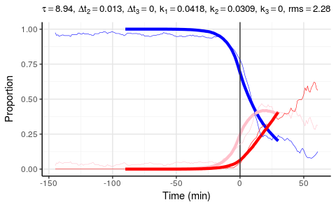

## SMC2

`r`r pars <- c3pars() free <- c(, 1, 2, 2) chr.smc <- cacheData(_SMC2_n10000_tau_k1_k2_dt2, fitChr, echr.smc, pars, free, nsim=10000, ntry=100, ncores=6, binDir=binDir) #plotTimelines(chr.smc, expdata = echr.smc, withpars=TRUE)

# 25/08/2017

Downloaded new data sets that John emailed me a few days ago. New set RAD21 and corrected sets SMC2, MK1775only and MK1775andICRF193.

`r`r plotTimelines(chr.smc, expdata = echr.rad, withpars=TRUE)

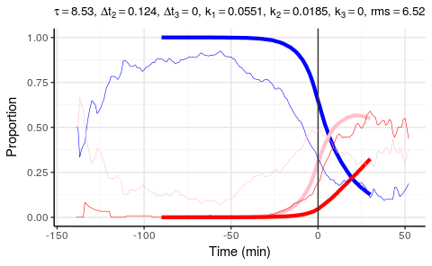

Talking to John and Tomo:

- change $\Delta t_n$ into $\tau_n$, that is, randomize it.
- for scramble add one more param: shift zero. Our definition of zero is not very accurate, so there might be a shift of a few minutes. Start with freezing $t_0$ for scramble.